# SNS(Instagram)을 이용한 카페 인기 지역 분석

- SNS는 트렌드의 변화가 실시간으로 기록되고 파악하기 쉬운 도구이다.
- 유명 SNS중 하나인 Instagram을 이용하여 카페 관련 게시글로 많이 업로드 되는 지역을 찾아 보고자 한다.

## 2. 워드클라우드(Word Cloud)

- 1장에서 크롤링한 데이터를 바탕으로 언급된 지역의 빈도수를 추출한다
- 추출된 빈도수를 바탕으로 워드클라우드 기법을 이용하여 시각화 한다.

### 1. 모듈 장착

```python
# basic module
import numpy as np
import pandas as pd
import matplotlib.pyplot as plt
from matplotlib import rc
rc('font', family = 'Gulim')

# extra module
import os
import glob
import re
import nltk
import wordcloud
from PIL import Image
```

### 2. 디렉토리 변경 및 데이터 불러오기

```python
os.chdir('C:/Users/ssmoo/Desktop/instagram_analysis/data/raw_data')
csv_name_list = glob.glob('*')
csv_file_list = []

for csv_name in csv_name_list:
    csv_file_list.append(pd.read_csv(csv_name))

insta_df = pd.concat(csv_file_list)
insta_df = insta_df.drop_duplicates() # 중복행 제거
insta_df = insta_df[insta_df['hashtag_list'].notnull()] # hashtag 결측치 제거
insta_df = insta_df.reset_index()
del insta_df['index']
```

### 3. 지역명 추출

- 사람들은 보통 지역이름과 카페를 붙여 카페가 위치한 지역을 나타낸다. ex) 연남동카페, 홍대카페...
- 이러한 특징을 이용하여 지역이름을 뽑아낸다.

#### 1. 카페로 끝나는 해시태그를 찾는 함수 생성 및 적용

```python
# 카페로 끝나는 해시태그 찾는 함수 생성
def get_cafe(text):
    cafe_regex = '[0-9a-zA-Z가-힣]*카페'
    cafe_compile = re.compile(cafe_regex)
    cafe_list = cafe_compile.findall(text)

    return cafe_list

# 함수 적용
cafe_list = []

for i in range(len(insta_df)):
    tmp_list = get_cafe(insta_df.loc[i, 'hashtag_list'])
    cafe_list += tmp_list

cafe_list[1:11]
```

```
['카페', '감성카페', '카페', '갬성카페', '브런치카페', '감성카페', '제주카페', '감성카페', '대학로카페', '혜화역카페']
```

- '카페'가 들어간 해시태그들을 추출하였지만 '감성카페', '브런치카페'와 같은 지역명이 나타나지 않은 해시태그들이 보인다.
- '카페'단어를 지워주고 '감성', '갬성', '브런치'와 같은 단어들을 찾아 불용어 처리해준다.
- '서울', '부산' 과 같은 광범위한 지역인 도시 이름들도 불용어 처리 해준다.

#### 2. '카페' 단어 제거 및 빈도수 딕셔너리 생성

```python
# '카페' 단어 제거
cafe_list_copy = cafe_list
cafe_list = []

for i in range(len(cafe_list_copy)):

    if len(cafe_list_copy[i]) > 2:
        cafe_list.append(cafe_list_copy[i][:-2])

# 빈도수 딕셔너리 생성
freqdist = nltk.FreqDist(cafe_list)
```

```python
freqdist.most_common(10)
```

```
[('서울', 670),
 ('감성', 661),
 ('예쁜', 608),
 ('분위기좋은', 522),
 ('부산', 342),
 ('디저트', 340),
 ('신상', 321),
 ('대구', 216),
 ('대전', 196),
 ('홈', 177)]
```

#### 3. 불용어 처리

- 빈도수 높은 순으로 상위 100개의 해시태그들중 지역명이 아닌 불용어들을 텍스트파일로 저장하였다.
- 도시 이름 또한 불용어 설정을 위해 텍스트파일로 저장하였다.

[figure not shown]

```python
from IPython.display import Image as im
im('C:/Users/ssmoo/Desktop/캡처.PNG')
```

```python
# 불용어 파일 불러오기
stopword = open('C:/Users/ssmoo/Desktop/instagram_analysis/data/raw_data/불용어.txt',
                encoding = 'utf-8')
stopword_list = stopword.readlines()

# 불용어 전처리
for i in range(len(stopword_list)):
    stopword_list[i] = stopword_list[i].replace('\n', '')

# 도시 이름 파일 불러오기
dosi = open('C:/Users/ssmoo/Desktop/instagram_analysis/data/raw_data/도시.txt',
            encoding = 'utf-8')
dosi_list = dosi.readlines()


# 도시 이름 전처리
for i in range(len(dosi_list)):
    dosi_list[i] = dosi_list[i].replace('\n', '')

for i in range(len(dosi_list)):
    dosi_list[i] = dosi_list[i].replace('시', '')

# 불용어 리스트에 도시 이름 추가
stopword_list += dosi_list

# 빈도수 딕셔너리에서 불용어 제거
for stopword in stopword_list:
    del freqdist[stopword]
```

### 4. 데이터 시각화 (워드클라우드)

#### 1. 단순 빈도수 그래프

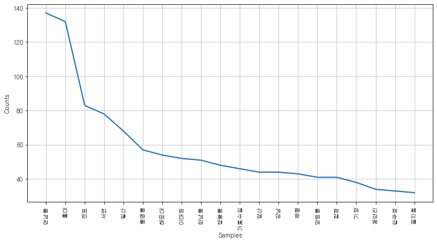

```python
plt.figure(figsize = (12, 6))
freqdist.plot(20)
plt.show()
```

- 그래프를 보면 연남동과 홍대가 다른 지역에 비해 압도적으로 많이 있다. 연남동과 홍대가 카페 인기 지역이라는 것을 유추할 수 있다.
- 부산 서면에 위치한 전포에 카페거리가 있어 전포 또한 빈도수가 높게 나온것으로 보인다.
- 단순 그래프로 확인했으니 워드클라우드를 이용하여 시각화 효과를 높여보자

#### 2. 워드클라우드

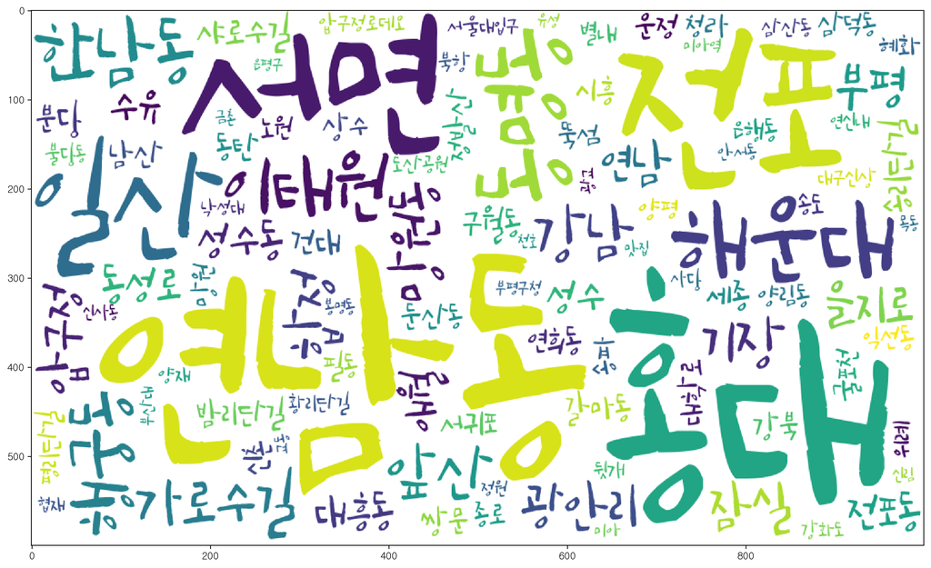

```python
wc = wordcloud.WordCloud(width = 1000,
                         height = 600,
                         background_color = 'white',
                         font_path = 'C:/Users/ssmoo/Downloads/SangSangFlowerRoad.otf',
                         max_words = 100)
plt.figure(figsize = (16, 10),
           dpi = 200)
plt.imshow(wc.generate_from_frequencies(freqdist))
plt.show()
```

- 언급 빈도수 상위 100개의 지역을 시각화하였다.
- 워드클라우드를 통하여 시각화하여 언급 빈도수가 높을 수록 글씨 크기를 크게 하였다.

#### 3. 그림 효과를 넣은 워드클라우드

- 카페 분석에 맞게 커피잔 이미지를 이용하여 워드클라우드를 해본다.

##### 커피잔이미지 불러오기 및 확인

[figure not shown]

```python
coffee_mask = np.array(Image.open('C:/Users/ssmoo/Desktop/coffee_cup.jpg'))
plt.figure(figsize = (8, 8))
plt.imshow(coffee_mask, cmap = plt.cm.gray, interpolation = 'bilinear')
```

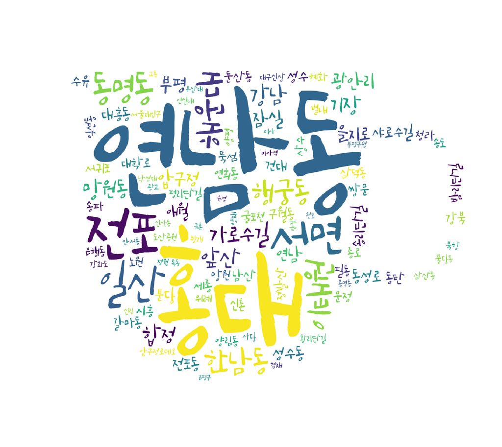

```python
wc = wordcloud.WordCloud(width = 1000,
                         height = 600,
                         background_color = 'white',
                         font_path = 'C:/Users/ssmoo/Downloads/SangSangFlowerRoad.otf',
                         max_words = 100,
                         mask = coffee_mask)
plt.figure(figsize = (10, 10),
           dpi = 200)
plt.imshow(wc.generate_from_frequencies(freqdist))
plt.axis('off')
plt.show()
```

## 3. 분석 의의

- 이로써 카페 인기 지역 분석 및 시각화를 완료하였다.
- 데이터 수집일은 19-11-27 하루였지만 지속적인 크롤링을 하면 카페 인기 지역 변화도 같이 분석 할 수 있을 것이다.
- 지속적인 크롤링과 함께 불용어 처리가 업데이트 된다면 분석력이 올라갈것이다.